# project_A02

### Machine Learning No.A02- Kaggle Competition

**Rescue stations**

Data : https://storage.googleapis.com/montco-stats/tz.csv Here is data from accidents that happen in city XYZ.

**Problem**:

Evil zombies have destroyed all central rescue stations in the city. The state has statistics where emergency problems occurred in last year (data above) and they are not sure whether the emergency stations were placed efficiently. Note that ambulances were sent only to EMS problems. Therefore, they asked us to find places where they should build 5 (of the same size) emergency stations. What will their position be?

```python
# importing libraries
import pandas as pd
import seaborn as sns
import gmplot
import matplotlib.pyplot as plt
from geopy.distance import vincenty
from IPython.display import Image
from IPython.core.display import HTML
from itertools import combinations
%matplotlib inline
```

```python
# Reading data from csv file and see what fileds we have in our data-set
df = pd.read_csv('tz.csv')
print(df.columns)
```

```
Index(['lat', 'lng', 'desc', 'zip', 'title', 'timeStamp', 'twp', 'e'], dtype='object')
```

```python
# take a look for the first 4 records
df[:2]
```

|  | lat | lng | desc | zip | title | timeStamp | twp | e |
| --- | --- | --- | --- | --- | --- | --- | --- | --- |
| 0 | 40.297876 | -75.581294 | REINDEER CT & DEAD END; NEW HANOVER; Station ... | 19525.0 | EMS: BACK PAINS/INJURY | 2015-12-10 17:40:00 | NEW HANOVER | 1 |
| 1 | 40.258061 | -75.264680 | BRIAR PATH & WHITEMARSH LN; HATFIELD TOWNSHIP... | 19446.0 | EMS: DIABETIC EMERGENCY | 2015-12-10 17:40:00 | HATFIELD TOWNSHIP | 1 |

2.1. In data-set above we have all problems in "Title" but according to the task that **"Note that ambulances were sent only to EMS problems"** we need to have just "EMS" problems; So, we have to subtract "EMS" from main data-set!

```python
# find just EMS Problems from main Data-set
emsDf=df[df['title'].str.contains("EMS")==True]
```

```python
# first top 5 EMS problems
ems_df = pd.DataFrame(emsDf.groupby('title').size().rename('counts'))
ems_df.sort_values(['counts'], ascending=[False], inplace=True)
```

```python
ems_df[0:3]
```

| title | counts |
| --- | --- |
| EMS: RESPIRATORY EMERGENCY | 6300 |
| EMS: CARDIAC EMERGENCY | 6231 |
| EMS: FALL VICTIM | 6148 |

Also, we have to know about top Towns that have EMS problems!

```python
# Top 5 Towns that have EMS problems!
ems_city_df = pd.DataFrame(emsDf.groupby('twp').size().rename('counts'))
ems_city_df.sort_values(['counts'], ascending=[False], inplace=True)
```

```python
ems_city_df[0:3]
```

| twp | counts |
| --- | --- |
| NORRISTOWN | 4787 |
| LOWER MERION | 4050 |
| ABINGTON | 3873 |

To better understand about number of EMS problems It's better to plot in **real geography map**. So, we can plot our data in real map because we have longitude and latitude.

```python
# Creating longitude and latitude variables
lats,longs= [],[]
```

```python
# adding all latitude from Data-frame to lats
for lat in emsDf['lat']:
    lats.append(lat)
```

```python
# adding all longitude from Data-frame to longs
for lon in emsDf['lng']:
    longs.append(lon)
```

```python
# using gmplot (open-source) library to plot
gmap = gmplot.GoogleMapPlotter(40.23,-75.33,10)
# plot heatmap
gmap.heatmap(lats, longs)
```

```python
# exporting result to html file
gmap.draw("tzems.html")
```

```python
%%HTML
<iframe width="100%" height="400"
src="tzems.html"></iframe>
```

[interactive chart not shown]

#### According to the map, now we can see in which town we have more EMS problems!

If we choice first top 5 towns from last result (that have most problems) to build EMS Station it will not be correct answer! why? because for example we have 2 towns which they have big EMS request but distance between their is not so far! (closed to each other)

What is the solution? If we find the distance between towns then it's possible to send other towns to main station (5 EMS station) and also another rule that is: we shouldn't build 2 EMS station to near to each other!

So, **finding the distance between towns and making cluster based on distance could be the best solution for this problem.**

#### NOTE: All distances are in real geographic system

```python
# calculate distance between towns
# group by town
distance=pd.DataFrame(emsDf.groupby('twp')['lat','lng'].apply(lambda x: x.mean()))
# reformating data-frame
distance=distance.add_suffix('').reset_index()
distance.sort_values(['twp'], ascending=[True], inplace=True)
sec_dis=distance
```

```python
# get distance by geopy library
def cal_distance(from_twn,to_twn):
    return round(vincenty(from_twn, to_twn).kilometers)
```

```python
# Creating a Data-frame for distance
columns = ['From_','To_', 'Distance_']
df_dis = pd.DataFrame(columns=columns)
distance=distance[0:34]
```

```python
# combinations towns to each other to then send coordinators to cal_distance to calculate distance and save in DF.

for i, j in list(combinations(list(distance.index),2)):
    from_dis=str((distance.iloc[i][1]))+','+str((distance.iloc[i][2]))
    two_dis=str((distance.iloc[j][1]))+','+str((distance.iloc[j][2]))
    dis=cal_distance(from_dis,two_dis)
    add_df = [distance.iloc[i][0], distance.iloc[j][0], int(dis)]
    df_dis.loc[len(df_dis)] = add_df
```

For example here is first 3 elements for distance (Km):

```python
df_dis[:3]
```

|  | From_ | To_ | Distance_ |
| --- | --- | --- | --- |
| 0 | ABINGTON | AMBLER | 10.0 |
| 1 | ABINGTON | BERKS COUNTY | 42.0 |
| 2 | ABINGTON | BRIDGEPORT | 19.0 |

```python
# Creating pivot from data-set
df_piv = df_dis.pivot('To_', 'From_', 'Distance_')
```

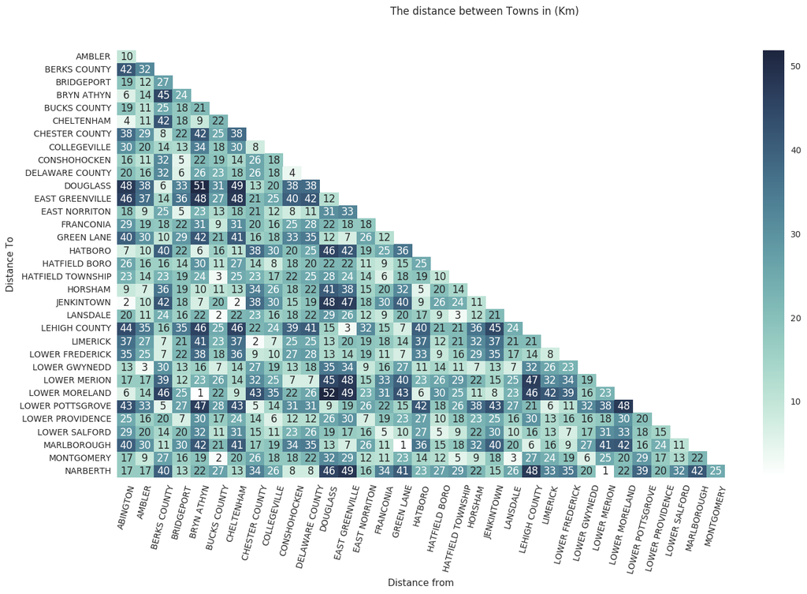

```python
# using seaborn to plot the results
sns.set(style="white")
cmap = sns.cubehelix_palette(as_cmap=True, rot=-.3, light=1)
ax = sns.heatmap(df_piv,label='small',annot=True,cmap=cmap)
ax.set_ylabel("Distance To")
ax.set_xlabel("Distance from")
plt.suptitle("The distance between Towns in (Km)")
plt.xticks(rotation=75)
ax.figure.set_size_inches(16,9)
```

I'll cluster this data on the assumption that there are 5 EMS. **I'll use the k-means alorithm.** In Pycluster there are two functions for doing k-means; "kcluster", which takes a point in N-dimensional space for each data element, and "kmedoids" which takes the full distance matrix.

```python
columns = ['From_','To_', 'Distance_']
df_dis = pd.DataFrame(columns=columns)
for i, j in list(combinations(list(sec_dis.index),2)):
    from_dis=str((sec_dis.iloc[i][1]))+','+str((sec_dis.iloc[i][2]))
    two_dis=str((sec_dis.iloc[j][1]))+','+str((sec_dis.iloc[j][2]))
    dis=cal_distance(from_dis,two_dis)
    add_df = [sec_dis.iloc[i][0], sec_dis.iloc[j][0], int(dis)]
    df_dis.loc[len(df_dis)] = add_df
df_piv = df_dis.pivot('To_', 'From_', 'Distance_')
```

```python
# reformating data-frame
mlDf=pd.DataFrame(df_piv)
mlDf=mlDf.add_suffix('').reset_index()
mlDf.columns.name = None
mlDf=mlDf.fillna(0)
```

```python
# dataframe looks like:
mlDf[:2]
```

|  | To_ | ABINGTON | AMBLER | BERKS COUNTY | BRIDGEPORT | BRYN ATHYN | BUCKS COUNTY | CHELTENHAM | CHESTER COUNTY | COLLEGEVILLE | ... | UPPER MERION | UPPER MORELAND | UPPER POTTSGROVE | UPPER PROVIDENCE | UPPER SALFORD | WEST CONSHOHOCKEN | WEST NORRITON | WEST POTTSGROVE | WHITEMARSH | WHITPAIN |
| --- | --- | --- | --- | --- | --- | --- | --- | --- | --- | --- | --- | --- | --- | --- | --- | --- | --- | --- | --- | --- | --- |
| 0 | AMBLER | 10.0 | 0.0 | 0.0 | 0.0 | 0.0 | 0.0 | 0.0 | 0.0 | 0.0 | ... | 0.0 | 0.0 | 0.0 | 0.0 | 0.0 | 0.0 | 0.0 | 0.0 | 0.0 | 0.0 |
| 1 | BERKS COUNTY | 42.0 | 32.0 | 0.0 | 0.0 | 0.0 | 0.0 | 0.0 | 0.0 | 0.0 | ... | 0.0 | 0.0 | 0.0 | 0.0 | 0.0 | 0.0 | 0.0 | 0.0 | 0.0 | 0.0 |

2 rows × 68 columns

```python
# save Towns names to list
names=[]
for name in mlDf['To_']:
    names.append(name)
```

```python
# 3 first elements
names[:3]
```

```
['AMBLER', 'BERKS COUNTY', 'BRIDGEPORT']
```

```python
# re-formating data-frame and creting a list for towns value from data-frame
mlDf.drop('To_', axis=1, inplace=True)
valtown=[]
for row in mlDf.iterrows():
    valtown.append(row[1])
listTownVal=mlDf.values.tolist()
```

```python
# Creating 5 cluster by kcluster
from Bio import Cluster
clusterids, error, nfound = Cluster.kcluster(listTownVal, 5)
```

```python
print("Cluster ids:", clusterids)
print("error:", error)
print("nfound:", nfound)
```

```
Cluster ids: [1 1 1 1 1 1 1 1 1 1 0 0 1 1 0 1 1 1 1 3 1 0 0 0 3 3 3 0 3 0 0 3 3 0 3 3 2
 0 3 3 2 2 4 2 2 2 2 2 4 2 2 2 4 2 4 2 4 4 2 2 2 4 4 2 4 4 4]
error: 3473.389895442573
nfound: 1
```

```python
# adding index with names of towns to dictionary
cities_in_cluster = {}
for name, clusterid in zip(names, clusterids):
    cities_in_cluster.setdefault(clusterid, []).append(name)
```

```python
# Showing off a nice module for when you have long text that
# should fold over multiple lines.
import textwrap
cluster_town=[]
for centroid_id, city_names in cities_in_cluster.items():
    print("EMS around: ", names[centroid_id])
    cluster_town.append(names[centroid_id])
    print('covering towns: ')
    text = ", ".join(city_names)
    for line in textwrap.wrap(text, 70):
        print("  ", line)
    print('\n')
```

```
EMS around:  AMBLER
covering towns:
   DOUGLASS, EAST GREENVILLE, GREEN LANE, LEHIGH COUNTY, LIMERICK, LOWER
   FREDERICK, LOWER POTTSGROVE, LOWER SALFORD, MARLBOROUGH, NEW HANOVER,
   PERKIOMEN


EMS around:  BERKS COUNTY
covering towns:
   AMBLER, BERKS COUNTY, BRIDGEPORT, BRYN ATHYN, BUCKS COUNTY,
   CHELTENHAM, CHESTER COUNTY, COLLEGEVILLE, CONSHOHOCKEN, DELAWARE
   COUNTY, EAST NORRITON, FRANCONIA, HATBORO, HATFIELD BORO, HATFIELD
   TOWNSHIP, HORSHAM, LANSDALE


EMS around:  BRIDGEPORT
covering towns:
   PENNSBURG, POTTSTOWN, RED HILL, ROYERSFORD, SALFORD, SCHWENKSVILLE,
   SKIPPACK, SOUDERTON, TELFORD, TOWAMENCIN, TRAPPE, UPPER FREDERICK,
   UPPER HANOVER, UPPER POTTSGROVE, UPPER PROVIDENCE, UPPER SALFORD, WEST
   POTTSGROVE


EMS around:  BRYN ATHYN
covering towns:
   JENKINTOWN, LOWER GWYNEDD, LOWER MERION, LOWER MORELAND, LOWER
   PROVIDENCE, MONTGOMERY, NARBERTH, NORRISTOWN, NORTH WALES, PHILA
   COUNTY, PLYMOUTH


EMS around:  BUCKS COUNTY
covering towns:
   ROCKLEDGE, SPRINGFIELD, UPPER DUBLIN, UPPER GWYNEDD, UPPER MERION,
   UPPER MORELAND, WEST CONSHOHOCKEN, WEST NORRITON, WHITEMARSH,
   WHITPAIN, WORCESTER
```

#### And then creating points in map to see EMS Locations!

```python
def map_center(town):
    return sec_dis[sec_dis['twp'].str.contains(town)]
```

```python
lat=[]
long=[]
for item in cluster_town:
    long.append(map_center(item).iloc[0][2])
    lat.append(map_center(item).iloc[0][1])
```

```python
import gmplot
gmap = gmplot.GoogleMapPlotter(40.23,-75.33,10)
gmap.scatter(lat, long, '#ff0000', size=1000, marker=False)
gmap.draw("mymap.html")
```

```python
%%HTML
<iframe width="100%" height="400"
src="http://shahryary.me/mymap.html"></iframe>
```

[interactive chart not shown]